# Ecological strategies of (pl)ants: Towards a world‐wide worker economic spectrum for ants - Gibb - Functional Ecology - Wiley Online Library

[Functional Ecology](https://besjournals.onlinelibrary.wiley.com/journal/13652435)

[Early View](https://besjournals.onlinelibrary.wiley.com/toc/13652435/0/0)

[figure not shown]

PERSPECTIVE

Open Access

# Ecological strategies of (pl)ants: Towards a world-wide worker economic spectrum for ants

[Heloise Gibb](https://besjournals.onlinelibrary.wiley.com/action/doSearch?ContribAuthorRaw=Gibb%2C+Heloise),

[Tom R. Bishop](https://besjournals.onlinelibrary.wiley.com/action/doSearch?ContribAuthorRaw=Bishop%2C+Tom+R),

[Lily Leahy](https://besjournals.onlinelibrary.wiley.com/action/doSearch?ContribAuthorRaw=Leahy%2C+Lily),

[Catherine L. Parr](https://besjournals.onlinelibrary.wiley.com/action/doSearch?ContribAuthorRaw=Parr%2C+Catherine+L),

[Jean-Philippe Lessard](https://besjournals.onlinelibrary.wiley.com/action/doSearch?ContribAuthorRaw=Lessard%2C+Jean-Philippe),

[Nathan J. Sanders](https://besjournals.onlinelibrary.wiley.com/action/doSearch?ContribAuthorRaw=Sanders%2C+Nathan+J),

[Jonathan Z. Shik](https://besjournals.onlinelibrary.wiley.com/action/doSearch?ContribAuthorRaw=Shik%2C+Jonathan+Z),

[Javier Ibarra-Isassi](https://besjournals.onlinelibrary.wiley.com/action/doSearch?ContribAuthorRaw=Ibarra-Isassi%2C+Javier),

[Ajay Narendra](https://besjournals.onlinelibrary.wiley.com/action/doSearch?ContribAuthorRaw=Narendra%2C+Ajay),

[Robert R. Dunn](https://besjournals.onlinelibrary.wiley.com/action/doSearch?ContribAuthorRaw=Dunn%2C+Robert+R),

[Ian J. Wright](https://besjournals.onlinelibrary.wiley.com/action/doSearch?ContribAuthorRaw=Wright%2C+Ian+J),

First published: 05 July 2022

https://doi.org/10.1111/1365-2435.14135

**Handling Editor** Matthias Schleuning

## Abstract

1. Current global challenges call for a rigorously predictive ecology. Our understanding of ecological strategies, imputed through suites of measurable functional traits, comes from decades of work that largely focussed on plants. However, a key question is whether plant ecological strategies resemble those of other organisms.
2. Among animals, ants have long been recognised to possess similarities with plants: as (largely) central place foragers. For example, individual ant workers play similar foraging roles to plant leaves and roots and are similarly expendable. Frameworks that aim to understand plant ecological strategies through key functional traits, such as the ‘leaf economics spectrum’, offer the potential for significant parallels with ant ecological strategies.
3. Here, we explore these parallels across several proposed ecological strategy dimensions, including an ‘economic spectrum’, propagule size-number trade-offs, apparency-defence trade-offs, resource acquisition trade-offs and stress-tolerance trade-offs. We also highlight where ecological strategies may differ between plants and ants. Furthermore, we consider how these strategies play out among the different modules of eusocial organisms, where selective forces act on the worker and reproductive castes, as well as the colony.
4. Finally, we suggest future directions for ecological strategy research, including highlighting the availability of data and traits that may be more difficult to measure, but should receive more attention in future to better understand the ecological strategies of ants. The unique biology of eusocial organisms provides an unrivalled opportunity to bridge the gap in our understanding of ecological strategies in plants and animals and we hope that this perspective will ignite further interest.

Read the free [Plain Language Summary](https://fesummaries.wordpress.com/2022/07/13/do-ants-and-plants-see-the-world-the-same-way-strong/) for this article on the Journal blog.

## 1 INTRODUCTION

Functional traits are characteristics of individual organisms that strongly influence their fitness or performance (McGill et al., 2006). A key benefit of functional traits is that they allow us to link organismal performance and physiological mechanisms across species and across ecosystems that do not share species. Frameworks that include functional traits have thus been proffered as a potential solution to limitations in the generality of ecological theory (McGill et al., 2006). Importantly, fundamental ecological or evolutionary trade-offs mean that many functional traits are interrelated and vary in a coordinated fashion, and can thus be thought of as representing dimensions of variation in *ecological strategy* (Westoby et al., 2002). Ecological strategies describe the way a species competes for resources, copes with disturbances, interacts with other species and its environment and, ultimately, determines its fitness and performance. Ecological strategy schemes have huge potential for organising knowledge and building general narratives about species and ecosystems, analogous to the role of the periodic table for chemistry (Southwood, 1977; Winemiller et al., 2015).

Despite its potential for predictive generality, the bulk of modern research on functional traits as proxies for ecological strategies of organisms has focussed on plants (e.g. Carmona et al., 2021; Díaz et al., 2016; Wright et al., 2002). This research has been successful in identifying a suite of ecological strategy dimensions along which all plants can be positioned. Each strategy dimension should clearly be *ecologically significant* (with regard to how the species makes a living or the conditions in which it performs best), and should also be underpinned by one or more *trade-offs*, meaning that there are both costs and benefits associated with any position along the dimension—generating a *spread of species* along the dimension. For the approach to be workable, the index traits need to be *easily measurable*, and the trait-based ranking of species along a given strategy dimension should be *broadly consistent* in the face of within-species variation (Westoby et al., 2002). Because they reflect physiological mechanisms governing tolerance of stress, competition and disturbance (Grime, 1977), plant ecological strategies also provide a means to predict responses to global change.

In response to advances in plant ecology, animal ecologists have amassed trait data but have been slower to identify common ecological strategies that would facilitate a predictive science in the face of global change (but see Cooke et al., 2019; Pigot et al., 2020). That said, considerable progress has been made in identifying universal biophysical rules of life (applicable to plants and animals) founded on energy balances and the fundamental scaling relationships of metabolism with body mass and temperature (Brown et al., 2004; Burger et al., 2019; Burger et al., 2021). In general, smaller, warmer organisms have faster metabolisms and shorter lives, but they also produce biomass (in the form of growth and reproductive output) at higher rates than larger, colder organisms (Burger et al., 2019; Junker et al., 2022). Pace-of-life theory similarly proposes that body size, metabolism and reproductive output are correlated to form slow–fast syndromes in response to resource availability, but with a primary focus on life-history traits (Ricklefs & Wikelski, 2002; Wikelski et al., 2003). These scaling laws may present inescapable constraints of physics and biology and therefore provide a bedrock upon which ecological strategies are constructed.

If plant-based trait ecology has advanced our understanding of ecological strategies, it is because it considered biophysical constraints in tandem with selective trade-offs on traits and structures involved in assimilation (acquisition of resources and maintenance) and production (growth and reproduction), directly linked to environmental conditions (Figure 1). This encompassing approach has helped unify the study of diverse plants along a continuum of minimal to maximal investment in organs related to resource acquisition (roots, leaves), structural support (stems, branches) and reproduction (flowers, seeds; Westoby et al., 2002; Díaz et al., 2016; Carmona et al., 2021). The allocation of resources is inherently economical in nature as it concerns investment of energy and resources into functional structures and traits that provide returns on investment in the currency of performance and fitness (Reich, 2014; Violle et al., 2007; Wright et al., 2004). Plants ‘invest’ in an ecological strategy of slow, medium or fast returns depending on the consistency of resources. For example, the limited and inconsistent availability of light, water and nutrients should promote a ‘safe’ and slow strategy (Reich, 2014). This economic–ecological strategy framework, with an emphasis on resource availability/variability, energy balance, assimilation and production presented in Figure 1 could be applied to animal systems, providing a powerful predictive tool.

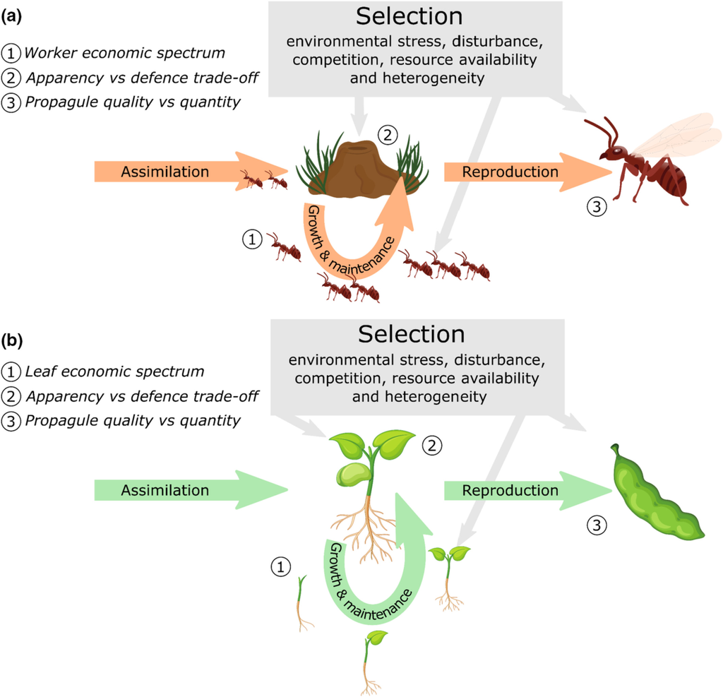

**FIGURE 1**

The environment drives the energetic balance of organisms, selecting for a range of ecological strategies. Examples for ants (a) and plants (b) are shown below. Energy assimilated from the environment is devoted to growth and maintenance or reproduction. Constraints of physics and biology limit the viability of ecological strategies, leading to trade-offs. Trade-offs (examples 1, 2 and 3 are detailed in the text) can occur at different scales within an organism, that is, at the colony or whole plant level, the organ level (e.g. ant workers or plant leaves) or the reproductive unit level (alate ants or plant seeds). The environment (both biotic and abiotic; and evolutionary history of a species) drives the ecological strategy of species, determining, for example, whether their investment in reproduction focuses on quantity or quality.

In this *Perspective*, we suggest ways to extend research on functional traits and ecological strategies in plants to ants and other eusocial animals. In eusocial animals, adult colony members care cooperatively for young, individuals are divided into reproductive and non- (or less) reproductive castes and generations overlap, resulting in what may be considered a ‘superorganism’, where collaboration of individuals results in selective pressures operating on individuals and the colony (Wilson & Sober, 1989). We focus on ants (the little things that run the world, Wilson, 1987) as a stepping stone to broader understanding and application of ecological strategies. Most ant species are central place foragers and allocate resources to non-reproductive colony members, which are specifically tasked with assimilation, providing a parallel to plant investment in acquisitive structures (Andersen, 1991; Andersen, 1995; López et al., 1994). We argue that they are therefore uniquely placed to bridge the gap in our understanding of plant and animal ecological strategies. Here, we explore opportunities to extend plant-based theory around ecological strategies to ants, highlighting the similarities and differences with plants. We propose a set of key ecological strategies for ants that parallel plant strategies and could be prioritised to advance generality in our understanding of the ecological strategies of organisms.

## 2 KEY ECOLOGICAL STRATEGIES OF ANTS THAT PARALLEL THOSE OF PLANTS

Recent reviews have recognised the value of quantifying ecological strategies as a means to understand diverse taxa such as terrestrial arthropods in which most species remain to be named, much less studied in detail (e.g. Brousseau et al., 2018; Moretti et al., 2017; Wong et al., 2019). However, the focus has been on specific traits or trait space, with less consideration of coordinated trait variation in ecological strategies resulting from trade-offs (Figure 2). Here, we consider how the latter more holistic approach may be extended to ants. Furthermore, we propose that ecological strategies initially considered for plants can help advance the study of eusocial taxa (Table 1), providing an opportunity for novel advances in our understanding of ecosystems. Below, we discuss several broad trade-off types and discuss the evidence for and against in ants, while also highlighting their parallels to plants.

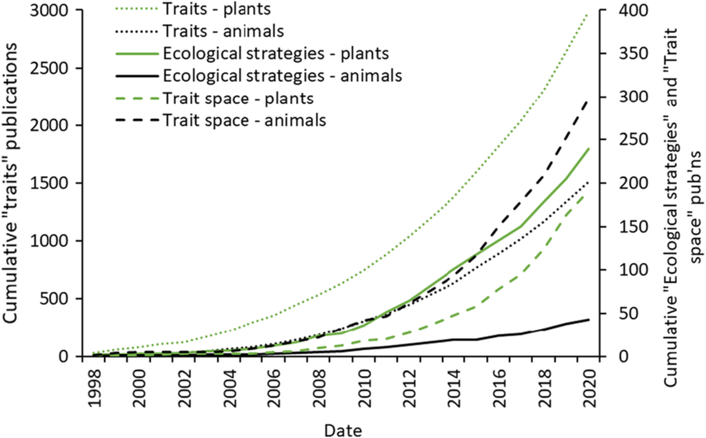

**FIGURE 2**

Cumulative publications using the terms ‘traits’, ‘ecological strategies’ and ‘trait space’ in the animal and plant literature from Web of Science between 1998 and 2020. Traits have been considered twice as often in publications relating to plants as animals. While ‘trait space’ is more common in the animal literature, the term ‘ecological strategies’ is used approximately five times more often in the plant literature. ‘Ecological strategies’ considers the coordinated trait variation resulting from ecological and evolutionary trade-offs. ‘Trait space’ represents the multidimensional position of species based on a range of measurable traits. Trait space may be used to predict ecological strategies, but does not explicitly hypothesise any trade-offs among traits. Search terms are provided in Appendix S1.

TABLE 1. Ecological strategy dimensions and their equivalents for plants and ants and other eusocial organisms and key traits to measure in ants. Most of these strategies are also broadly applicable to non-eusocial animals. CT<sub>max</sub> (or the critical thermal maximum) is the temperature at which a given species loses its ability to right itself

| Ecological strategy dimension | Plants | Ants and other eusocial organisms | Key traits to measure in ants |
| --- | --- | --- | --- |
| Fast–slow life spectrum | Leaf economic spectrum (Reich et al., 1997; Wright et al., 2004), Wood economics spectrum (Chave et al., 2009), Whole plant economics spectrum (Reich, 2014) | Worker economic spectrum (see Box 1) | Worker mass density Resource harvesting rate Worker N, P Metabolic rate Life span |
| Propagule size and number trade-off | Seed mass–seed output trade-offs (Moles et al., 2005; Westoby et al., 1996) | Queen size versus queen number trade-offs or budding versus nuptial flights (Heinze & Rueppell, 2014; Helms & Kaspari, 2015; Wiernasz & Cole, 2003) | Queen size (Weber's length) Measure of gyny (e.g. queen number) Colony reproduction (budding, nuptial flights, mixed) |
| Apparency-defence trade-off | Plants that are more apparent invest more in defence (Feeny, 1976) | Colony size versus susceptibility to natural enemies (Adler, 1999; Lebrun & Feener, 2007) | Colony biomass, worker number and growth rate Allocation to reproductives, Voltinism Natural enemies, defensive morphology (e.g. spines), presence of sting or other chemical defence |
| Resource acquisition trade-offs | Root growth strategies–fast–slow and symbioses (Bergmann et al., 2020; Carmona et al., 2021) | Trophic position (carnivore-herbivore spectrum) or foraging strategy, e.g. discovery–dominance trade-off (Davidson et al., 2003) | Mandible/clypeus morphology, trophic level Individual versus group foraging Worker polymorphism Time to resource discovery Monopolisation of resources Worker brain size Mutualisms |
| Stress-tolerance trade-offs | Leaf size–twig size trade-offs (light interception vs. stress tolerance; Westoby & Wright, 2003) | Trade-offs in physiological tolerance versus resource acquisition (Bestelmeyer, 2000; Lessard et al., 2009; Yela et al., 2020) | Worker body size, worker mass density CT<sub>max</sub>, desiccation tolerance, activity periods Cuticle colour (thermal melanism), Resource acquisition (discovery time, monopolisation) |
| Habitat structure | Not described | Adaptation to one microhabitat element commonly disadvantages species in another (e.g. the size-grain hypothesis, Kaspari & Weiser, 1999) | Worker body size Femur length Eye size/position Scape length |

### 2.1 Fast–slow life spectrum: The worker economic spectrum

Particularly appealing is the opportunity to explore parallels between workers from ant colonies and the leaves of plants (Wright et al., 2004). The leaf economics spectrum (LES) describes correlated variation among a suite of traits representing a fundamental trade-off between the rapid acquisition of resources and conservation of resources in well-protected tissues (Diaz et al., 2004). Similar fast–slow spectra have been developed at a whole organism scale for animals, such as pace-of-life syndromes (e.g. Brown & Sibly, 2006). Like plants, however, eusocial organisms invest in ‘structures’ (non-reproductive individuals) that are specifically tasked with assimilation of resources. Key traits from the leaf economics spectrum (LES) have parallels in ants and we propose that these make up a worker economics spectrum (Box 1), representing a ‘slow’ or ‘fast’ lifestyle.

### BOX 1. Is there a worker economic spectrum for ants that parallels the leaf economic spectrum for plants?

Like plants, ants are largely sessile and are modular organisms. Ecologists have long noted similarities between ants and plants (Andersen, 1995). Can we extend theory about ecological strategies developed using plants to ants, using measurable traits?

The world-wide leaf economic spectrum (Wright et al., 2004) describes multivariate correlations that constrain leaf traits primarily to a single axis of variation. Leaves may be placed on a spectrum from ‘slow’ to ‘quick’ return on investments of nutrients and dry mass that is largely independent of growth form, plant functional type or biome. Leaf traits all have parallels in ant workers, which are the resource harvesting unit of the colony (Table B1; Figure B1).

TABLE B1. LES traits and hypothesised ant worker economic spectrum parallels

| Leaf trait (units) | Worker ant trait (units) |
| --- | --- |
| Leaf mass per unit area (g/m<sup>2</sup>) | Worker mass density (g/m<sup>3</sup>) |
| Photosynthetic capacity (nmol g<sup>−1</sup> s<sup>−1</sup>) | Resource harvesting rate (J/s) |
| Leaf N, P concentration (g/g) | Worker N, P concentration (g/g) |
| Dark respiration (nmol g<sup>−1</sup> s<sup>−1</sup>) | Standard metabolic rate (μl CO<sub>2</sub>/s) |
| Life span (days) | Life span (days) |

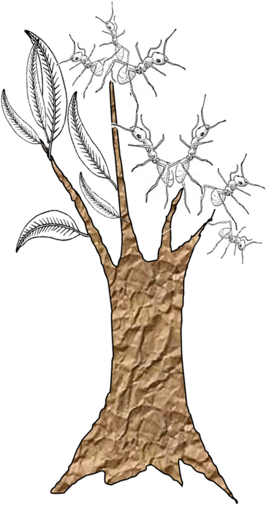

**FIGURE B1**

Parallels between ants and leaves, showing ants as the leaves of the colony.

### 2.2 Propagule size and number trade-offs

A trade-off between propagule size and number (seed size and number for plants, Leishman et al., 2000; Westoby et al., 2002; Moles et al., 2005) is likely to be common to all taxa because the ability of an individual to invest in reproduction is limited. This trade-off also features in *r-K* selection theory (MacArthur & Wilson, 1967). A greater number of low-mass propagules enhances a species' ability to reach all the empty microsites within a habitat. On the other hand, large propagules are capable of outcompeting small propagules when in direct competition and are better at tolerating adverse conditions. In this context, for ants, the propagules are the alates (virgin queens and males) and resulting founding queens, rather than eggs, since only eggs that become alate queens can start new colonies. Colonies also face trade-offs between the quality and quantity of males, and males face trade-offs in the size and number of their sperm. There are a range of ways in which ants can modify the size of their propagules. Species with larger colonies produce proportionally fewer, but larger alates of both sexes, suggesting that there is a trade-off between alate size and number (Shik, 2008), as for plant seeds. Body reserves are important in determining the number of workers a new queen can produce and whether she will need to risk foraging for herself (non-claustral colony founding) or is able to produce enough workers to remain enclosed in her nest (claustral colony founding; Keller & Passera, 1989; Stille, 1996; Brown & Bonhoeffer, 2003; Peeters & Molet, 2010). Ants can also invest in propagules through ‘dependent’ colony founding, whereby new queens are assisted by workers from the parent nest (and can therefore disperse only small distances; equivalent to vegetative propagation in plants) and ‘independent’ colony founding, where queens are not assisted and are therefore able to establish new colonies at greater distances from the parent nest, but with lower establishment success (Keller, 1991). Dependent colony founding can also be exploited by socially parasitic ants (Buschinger, 1986; Buschinger, 2009). Ants may therefore display the dispersal-establishment trade-off through queen size and number, but the ‘size’ of the queen can be supplemented by accompanying workers or by queen foraging in the early stages of colony establishment.

### 2.3 Apparency-defence trade-offs

Plants that are more obvious (apparent) to herbivores, for example by being large, have more natural enemies (Dai et al., 2017; Schlinkert et al., 2015). As a result, they are expected to invest more in defensive structures and compounds (Feeny, 1976; but see Smilanich et al., 2016). In parallel, for ants we might also expect that larger colonies would attract a greater natural enemy load and might therefore invest more in defence. For ants, colony defence depends on the number of workers and features such as worker aggression, morphology and stings or other chemical weapons, as well as structural defence of the nest (Dornhaus & Powell, 2010). Furthermore, because large colonies are more attractive to predators, the likelihood of an ant nest escaping vertebrate predation increases with increasing polydomy (where a colony's brood and workers are distributed across multiple smaller nests, thus reducing its apparency; Van Wilgenburg & Elgar, 2007). While the polydomy literature has focussed on its foraging benefits (e.g. Burns et al., 2021; Stroeymeyt et al., 2017), a major advantage of polydomy may be in spreading the risk of predation and isolating nests from infections by pathogens and parasites (Le Breton et al., 2007; Robinson, 2014). Species with large, polydomous colonies are also more likely to by polygynous (i.e. have multiple queens). Polygyny is in turn correlated with dependent colony founding and ecological dominance (Boulay et al., 2014) and hypothesised to be associated with morphological differentiation in the worker caste (worker polymorphism; Bourke, 1999; Anderson & McShea, 2001), with fast-growing colonies investing more in soldier castes (Kaspari & Byrne, 1995). Furthermore, polygyny may facilitate social parasitism because colonies accept returning young queens (Buschinger, 1990). At the other end of the spectrum, small monogynous colonies with limited or no worker polymorphism, may be less well defended, but have higher reproductive potential. Such characteristics are suited to variable resource environments and isolated habitats, where rapid colonisation at a distance from the colony of origin is advantageous (Bourke, 1999; Burchill & Moreau, 2016; Heinze & Rueppell, 2014; Zahnd et al., 2021). Colony size may thus be associated with a suite of colony traits that contribute to an ecological strategy related to the ability of species to take advantage of resources, based on their spatial and temporal variability.

### 2.4 Resource acquisition trade-offs

A key difference between plants and ants is that plants forage for above- and below-ground resources with different organs (roots vs. leaves), whereas ant workers forage for all resources required by the colony (although there can be division of labour among workers, even when they are morphologically similar [Gordon, 1996]). Foraging below-ground by plant roots is essential for growth. Roots not only forage for nutrients and water, but are important in physical anchoring, resource storage and vegetative reproduction (Kramer-Walter et al., 2016). For ant workers, there are parallels with resource storage (the ‘social stomach’ and repletes, which act as storage organs in some species, e.g. honeypot ants), and vegetative reproduction (workers accompany founder queens in species where dependent colony founding occurs). There is substantial trait variation in plant roots, which has been suggested to follow a root economics spectrum of fast–slow (conservative–acquisitive; Díaz et al., 2016), similar to the LES and worker economic spectrum discussed above.

More recently, Bergmann et al. (2020) suggested that most variation in fine root traits comes not from a classical fast–slow gradient, but from a ‘collaboration’ gradient in resource uptake, ranging from ‘do-it-yourself’ to complete ‘outsourcing’ to mycorrhizal fungi. Here, the plant–fungal interaction dimension is defined by a trade-off between the morphological traits of root diameter and specific root length. In parallel to these plant–fungi symbioses, mutualisms that allow access to fungal resources and plant sugars are important in the evolutionary success of ants (Davidson et al., 2003; Heil & McKey, 2003; Mueller et al., 1998). Plant sugars are available to ants in liquid forms such as honeydew (the excreta of mutualist insects, such as aphids) and extrafloral nectar. The morphology of mouth parts in ants may reflect differences in feeding strategies, for example, liquid feeding is linked with the length of the clypeus of ant workers (Davidson et al., 2004). In Box 2, our analysis shows that clypeus length and mandible length act in opposite directions (axis 3), representing the trade-off between liquid feeding and trophic level. The spectrum from hunters to husbandry (honeydew farmers) is thus represented in one of the major axes in the external morphospace of ant workers. The highly specialised morphologies of predatory ants, such as the sickle-shaped mandibles of *Plectroctena* and the trap-jaw mechanism of *Odontomachus* (Dejean et al., 2001; Larabee & Suarez, 2015) may also impede tending of honeydew-producing insects. Davidson et al. (2004) identified further morphological trade-offs between defensive structures (such as hypertrophied mandibular glands or a more rigid gaster) and the storage capacity of structures that allow ants to harvest and transport liquids (e.g. the crop).

### BOX 2. What does ecological strategy space look like?

What does ant ecological strategy space look like? While we do not have comprehensive data available on detailed natural history and various physiological and reproductive trade-offs (see main text), wide-ranging data on worker ant morphology do exist (Gibb et al., 2018; Parr et al., 2017). Worker morphology undoubtedly influences the way that ants interact with their environment, but it is less clear if and how worker morphology may scale to influence colony fitness and growth. Regardless, we argue that leveraging these data to gain an initial understanding of strategy variation among worker ants across species—the ‘leaves’ of the tree—is a valuable exercise.

We use the morphological data held in the GlobalAnts database (Gibb et al., 2017; Parr et al., 2017) to summarise variation in ant worker morphology. We applied a principal component analysis (PCA) to the trait data and retained four principal dimensions for interpretation (see Appendix). From the 3003 ant species from across the globe in our dataset, capturing all major lineages of the group and encompassing ~22% of described taxonomic diversity (13,687 species in [AntCat.org](http://antcat.org/)), we recovered a multivariate trait space defined by four dimensions. We interpret the dimensions based on existing knowledge of ant trait–habitat associations, behaviour and biomechanics (Parr et al., 2017) and through comparison to independent datasets on ant ecology and evolution (see Appendix S2).

The first plane, made up of the first two principal dimensions, accounts for 58% of the variability in ant morphology (Figure B2a). We interpret this plane as primarily relating to microhabitat specialisation: it describes a gradient from small, robust (i.e. compact, with relatively short appendages) ants with laterally positioned eyes (top left) to larger, more gracile ants with dorsally positioned eyes (bottom right). This gradient in morphology is associated with a gradient in ecology: the smaller, robust species are typically evolutionarily older, subterranean and predacious, whereas the larger, gracile species are younger, more likely to live in the canopy, and have more complex foraging strategies and liquid feeding behaviours (Figure B2a). This pattern of variation in ant morphology captures the Dynastic-Succession hypothesis: an idea which describes the evolutionary arc of ants beginning in the soil as obligate predators, before invading the high canopy and developing more complex feeding and foraging behaviours through evolutionary time (Lucky et al., 2013; Moreau & Bell, 2013; Wilson & Hölldobler, 2005). A separate gradient (ranging from bottom left to top right) also describes variation from narrow-headed species with small feeding parts to wide-headed species with large feeding parts. This second gradient does not appear to be strongly associated with the independent ecological data.

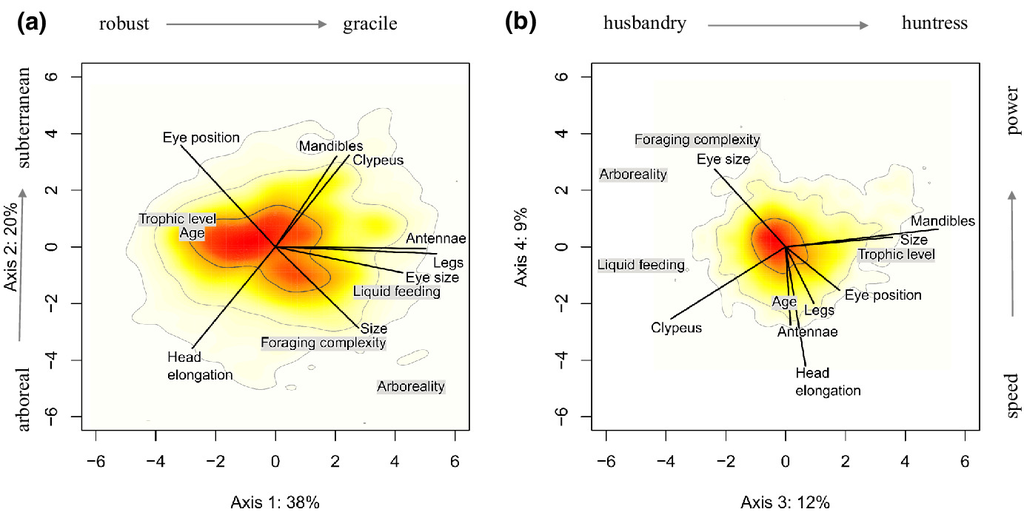

**FIGURE B2**

Global ant morphological trait space. Heat colour represents the density of species in each plane (redder colours = more species). Grey contours represent the 50th (inner), 95th and 99th (outer) percentiles. Arrows represent correlations of traits with the PC axes. All morphological traits are relative to size except size itself. Position of the independent data (shaded in grey) represents their correlation with the PC axes. Arrows not drawn for the independent data for visual clarity. Correlations are scaled differently between each panel, and between the trait and independent ecological datasets for visual clarity. Percentages in the axis labels indicate the fraction of total worker ant morphological variation captured by each axis.

The second plane, composed of dimensions 3 and 4, accounts for 21% of total ant morphological variation. This plane is best understood as two separate dimensions, and we interpret it as primarily relating to dietary differentiation (Figure B2b). Axis 3 describes variation from husbandry to hunters: small, liquid feeding species with short mandibles but large clypei are found at one extreme (left, Figure B2b), and larger, predatory species with long mandibles and short clypei are found at the other (right, Figure B2b). Finally, axis 4 describes a gradient of narrow-headed species with small eyes (bottom, Figure B2b) to wide-headed species with larger eyes (top, Figure B2b). Head shape is associated with mandibular closing speed. Narrow heads allow for rapid but relatively weak movement, while wide heads can only close their mandibles slowly, but with much larger forces (Gronenberg et al., 1997).

Species may also trade-off traits that allow them to discover resources rapidly (favouring dispersed resources), against traits that allow them to effectively defend those resources (favouring clumped resources). The discovery–dominance trade-off in ants is hypothesised to be a crucial ecological strategy dimension allowing the coexistence of different ant species and can be considered analogous to a colonisation–competition trade-off (Fellers, 1987). Ant colonies can succeed in foraging by investing in fewer costly large worker brains (brain size is correlated with body size) or many small worker brains (large colonies; Feinerman & Traniello, 2016). We suggest that the discovery–dominance trade-off might be a result of ants with large bodies and brains being well equipped to discover resources, while those with large colonies and small brains are well placed to defend resources. However, the trade-off does not occur in many ant assemblages and is broken by species with enhanced abilities to access plant sugars (through mutualisms, as described above), which provide them with energy to excel at both dominance and discovery (Davidson, 1998; Parr & Gibb, 2012; Stuble et al., 2013).

### 2.5 Stress-tolerance trade-offs

Response to stress has long been recognised as a key dimension of a species' ecological strategy. Indeed the stress axis contributes the ‘S’ in Grime's (Grime, 1977) C-S-R scheme, and this axis is central to the leaf economic spectrum. Less obviously, variation in the size of leaves and the structures that support them (twigs) may in part be understood as a stress-related strategy spectrum. The leaf size-twig size spectrum describes variation in plant species from those with narrow, frequently branched twigs that bear small leaves to those with thick twigs that bear large leaves (Westoby & Wright, 2003). Larger leaves capture more light and have cheaper twig support costs per unit leaf area, but are more prone to over-heating during hot, dry conditions and to frost damage on cold, clear nights; thus the leaf size-twig size trade-off may represent a trade-off between climate (stress) tolerance and photosynthetic capability (‘light foraging’; Wright et al., 2017). Similarly, in ants, species with large colonies and aggressive workers dominate resources, but are often unable to tolerate extreme temperatures, leaving a temporal window of opportunity for thermophilic ants in hot climates or cryophilic ants in cold climates (Bestelmeyer, 2000; Cerda et al., 1998; Fitzpatrick et al., 2014; Lessard et al., 2009). The poor performance of these climate specialists during peak ant activity times suggests that thermal tolerance is costly. Recent work further suggests that persistence in extremely hot and dry climate also favours ant species exhibiting worker polymorphism, perhaps owing to size-related differences in thermal tolerance within the colony (La Richelière et al., 2022).

### 2.6 Trait covariance in adaptation to microhabitats

Traits related to habitat use often covary and are central to consideration of how ants (and other animals) persist in, and are limited to, particular physical environments (e.g. Andersen, 2019; Bihn et al., 2010; Gibb et al., 2015; Gibb et al., 2018; Gibb & Parr, 2010; Kaspari & Weiser, 1999; Parr et al., 2017; Silva & Brandão, 2010). There is less discussion of this for plants (but see Antos, 1988; Elberse & Berendse, 1993; Xu et al., 2008), probably because plants make up much of the habitat (for animals) and plant–plant interactions may be considered in the context of competition. Covariance in traits, dictated by the external environment, is apparent in multidimensional morphospace (e.g. Silva & Brandão, 2010; Sosiak & Barden, 2021), such that species are distributed along axes of morphological variation. For example, ants with long legs tend to have larger, dorsally positioned eyes because these characteristics are favoured in open habitats; in contrast, species with short legs and small, laterally positioned eyes do better in more complex habitats (Gibb & Parr, 2013). In Box 2, we show that many external morphological traits covary (Figure B2).

## 3 DIFFERENCES IN STRATEGIES BETWEEN PLANTS AND ANTS

Along with these parallels, we also expect differences between ant and plant strategies: ants are heterotrophs that forage for chemically complex foods containing (among many other things) the macronutrients carbohydrates, lipids and proteins (Krabbe et al., 2019). In contrast, plants are autotrophs whose roots ‘forage’ for specific elements (e.g. N, P, K) while their leaves provide energy through photosynthesis. Yet, the performance of ants and plants similarly depends on stoichiometric ratios of carbon, nitrogen and phosphorous (C:N:P), as well as a suite of other elements (e.g. Na, Fe, Ca, etc.). For instance, nitrogen is important in both structural and chemical defence in plants (Fernández-Martínez et al., 2018; Onoda et al., 2017), while playing an analogous role in the thickness of cuticles and the production of volatile chemical defence in ants (Buxton et al., 2021; Davidson, 2005; Peeters et al., 2017). Moreover, while the elemental composition of plant tissues and the distributions of species themselves have been linked to the elemental composition of soils (John et al., 2007; Laliberte et al., 2012), whether and how local and regional distributions of elements (Kaspari & Powers, 2016) govern aspects of ant nutritional physiology, ecological strategy and community composition remain less resolved. Ant consumers further differ from plants because they span trophic levels from near herbivorous to predatory (Davidson et al., 2003). Of course, some plants are carnivorous or parasitic, but these species tend to be treated as special cases, whereas trophic diversity is the rule in ants.

## 4 UNIFYING TRADE-OFFS IN AN ENVIRONMENTAL CONTEXT

Many of the trade-offs considered here are interrelated, but may act on different components of the organism, as shown in Figure 1. The environmental pressures of stress, disturbance and competition are expected to direct species evolution through the coordinated variation that makes up an ecological strategy. In plants, for example, the biogeography of soil productivity explains much of the variation in coordinated leaf traits (Wright et al., 2002). On older soils of low P availability, many plants in the community have higher root and leaf density, low N, low P and low photosynthetic capacity per unit leaf area, which are all traits correlated with a slow-return economic strategy (Reich, 2014). For ants, resource-rich environments may select for a fast strategy whereby colonies that rapidly produce large numbers of active and aggressive workers have a competitive advantage in accessing mutualists or other resources (e.g. tropical rainforest canopies, Davidson et al., 2003). These cheaper workers may be short-lived and expendable due to low per capita investment in body structures (Peeters et al., 2017), may require fast metabolic rates to maintain high activity, and may be a more attractive resource for natural enemies and more vulnerable to temperature stress. Resource-rich environments may also support species with the opposite strategy as competitively dominant species may create resource scarcity for other species.

Another key question is whether economic strategy is linked to reproductive strategy. For example, faster resource acquisition should allow for faster re-deployment of those resources into reproductive parts. In eusocial animals, however, the tasks of growth and survival are decoupled from reproduction. Queens break the fundamental trade-off between longevity and reproduction rate that dictates life history for most non-eusocial organisms because they have outsourced the costs of survival to workers (Keller & Genoud, 1997). This is taken even further by colonies with dependent founding, where new queens are taken back by the parent colony, thus prolonging the reproductive life of the colony, independent of investment in individual growth or reproductive units (Cronin et al., 2013). On one hand, we would predict that the worker economic spectrum would be correlated with reproductive rate depending on the environmental context (Figure 1), but on the other, the decoupling of survival and reproduction in eusocial organisms presents the fascinating possibility that different selective pressures from the environment could act independently to create mixed ecological strategies. We are not aware of parallels outside of eusocial organisms for this opportunity to overcome the trade-off between longevity and the quality of offspring and growth.

Trade-offs associated with adaptations to habitat structure may largely act independently of the trade-offs associated with economic or pace-of-life spectra. However, stress or disturbance associated with particular microhabitat types may limit ecological strategies, for example, species with slow growth rates may not be able to persist in highly disturbed microhabitats, such as stream banks that experience regular flooding.

## 5 FUTURE DIRECTIONS IN ECOLOGICAL STRATEGY DIMENSIONS

### 5.1 Current data strengths and opportunities

Several online databases store data on traits of ants that could be used to build our understanding of ant ecological strategy dimensions. These databases include the Global Ant Database ([globalants.org](http://globalants.org/)), which focuses on local assemblage composition and morphological traits, and includes life-history traits (Gibb et al., 2017; Parr et al., 2017); AntWeb ([www.antweb.org](http://www.antweb.org/)), which is taxonomically focused, but includes data on life history and ecology, distribution and morphology (Fisher & Ward, 2002); and Ant Profiler, which focuses on life-history traits and ecology (Bertelsmeier et al., 2013). Distributional records are the focus of the Global Ant Biodiversity Informatics (GABI) Project (Guenard et al., 2017). Genomes are being collated through Fourmidable (Wurm et al., 2009), the Hymenoptera Genome Database (Munoz-Torres et al., 2010) and the Global Ant Genomics Alliance (GAGA, Boomsma et al., 2017). Much of the focus of data collection has been on traits relevant to habitat use and trophic role. In Box 2, we show how morphological data from the Global Ants Database can be used to understand how suites of traits change in response to the evolution from the ancestral predatory soil-living solitary foraging state of ants to the surface-living liquid feeding group foraging state of ants that dominate many contemporary ecosystems.

When we consider the life-history strategies of ants, data are available to test many of the ideas considered above for a subset of species but are not yet extensive enough to address key strategy dimensions at a global scale. Several traits are common in the literature, but not yet integrated into databases: physiological traits such as CT<sub>max</sub> have been central to climate-related research on ants in recent years (Diamond et al., 2012; Leahy et al., 2021; Penick et al., 2017; Roeder et al., 2021); dietary traits, such as nitrogen stable isotope composition, have been used extensively in recent studies that explore the position of ants on a spectrum from herbivores to predators (Davidson, 2005; Davidson et al., 2003; Gibb & Cunningham, 2013); and key life-history traits such as colony size, have featured in studies that cover a broad range of species (e.g. Burchill & Moreau, 2016; Kaspari & Vargo, 1995). Other traits, such as worker or queen life span (Keller, 1998; Kramer & Schaible, 2013), are more difficult to obtain but are crucial to understanding ecological strategies.

### 5.2 Where should we direct future efforts?

Concerted efforts to measure traits that would allow us to make direct comparisons with the ecological strategy dimensions of plants would be valuable. We suggest starting with measures that directly parallel those of plants as the most likely route through which to achieve a shared understanding and we list a range of traits associated with the strategies discussed above in Table 1. Development of a ‘Worker economic spectrum’ model to directly parallel that of the LES of plants (Box 1) is an obvious starting point, but requires traits such as metabolic rate, life span and resource harvesting rates, which can be expensive to measure or difficult to standardise. A focus on understanding the covariance of traits within and across ecological strategies may lead us to more easily measured traits associated with these key economic spectrum traits, but it is important to strongly establish these relationships before proceeding with indicator traits. Furthermore, exploring links between economic spectrum traits for both reproductive and growth (worker) components (Figure 1), as well as whole colonies, would allow us to ask whether ecological strategies at different organisational levels in eusocial organisms are linked.

Species loss will impact the diversity of ecological strategies and a stronger understanding of ecological strategies will allow us to better predict this change and target conservation efforts (Cooke et al., 2019). To take this further, it would be exciting to link changes in ecological strategies with feedbacks to the environment to assist in predicting the impacts of change at local and global scales. The traits making up the ecological strategies discussed here would mostly be categorised as ‘response traits’; in contrast, ‘effect traits’ describe the impact of a species on the ecosystem (Suding et al., 2008). For example, traits such as ‘resource harvesting’ or metabolic rate may provide a useful indication of the rate at which a species uses resources and therefore the magnitude of its impact on an ecosystem. Identifying where different ecological strategies result in different outcomes for ecosystems would significantly improve our power to predict the impacts of species turnover on the environment.

AUTHORS' CONTRIBUTIONS

H.G., I.W., T.R.B., L.L., N.J.S. and C.L.P. made substantial contributions to conception and design; H.G. and I.J.W. drafted the article. All authors revised the manuscript critically for important intellectual content, gave final approval for publication and agree to be accountable for aspects of the work they conducted.

## ACKNOWLEDGEMENTS

H.G. and I.J.W. were funded by the Australian Research Council (DP210101630), J.Z.S. was funded by a European Research Council Starting Grant (ELEVATE: ERC-2017-STG-757810); T.R.B. was funded by the Leverhulme Trust (ECF-2017-208); JPL was supported by a NSERC Discovery Grant (RGPIN-2015-06081) and the Concordia University Research Chair in Biodiversity and Ecosystem Function; J.I.-I. was funded by NSERC-CREATE in Biodiversity, Ecosystem Services and Sustainability (BESS). Open access publishing facilitated by La Trobe University, as part of the Wiley - La Trobe University agreement via the Council of Australian University Librarians.

## CONFLICT OF INTEREST

There is no conflict of interest.

## REFERENCES

[figure not shown]

[figure not shown]